# EC0866: Wildfire-specific fine particulate matter and hypertensive disorders of pregnancy in the U.S. ECHO-wide cohort

Primary Adjusted Model: T3_smoke_days_over5

| Term | OR | 95% CI Low | 95% CI High | P-value |
| --- | --- | --- | --- | --- |
| Intercept | 0.170 | 0.117 | 0.246 | 0.0000 |
| T3_smoke_days_over5 (exposure) | 1.002 | 0.988 | 1.017 | 0.7630 |
| Maternal age (term 1) | 0.872 | 0.625 | 1.217 | 0.4196 |
| Maternal age (term 2) | 1.186 | 1.112 | 1.265 | 0.0000 |
| Education: High school | 0.839 | 0.669 | 1.053 | 0.1299 |
| Education: Some college | 0.906 | 0.731 | 1.124 | 0.3704 |
| Education: Bachelor’s degree | 0.693 | 0.550 | 0.872 | 0.0018 |
| Education: Postgraduate degree | 0.577 | 0.453 | 0.734 | 0.0000 |
| Parity (1) | 0.584 | 0.521 | 0.654 | 0.0000 |
| Parity (2) | 0.484 | 0.412 | 0.569 | 0.0000 |
| Parity (3+) | 0.511 | 0.419 | 0.622 | 0.0000 |
| Race: Black | 1.306 | 1.089 | 1.568 | 0.0041 |
| Race: Asian | 0.603 | 0.457 | 0.797 | 0.0004 |
| Race: AI/AN | 0.580 | 0.373 | 0.901 | 0.0155 |
| Race: Other/multiple | 0.661 | 0.482 | 0.907 | 0.0102 |
| Ethnicity: Hispanic (any race) | 0.915 | 0.782 | 1.070 | 0.2674 |
| Infant sex (male) | 1.059 | 0.966 | 1.161 | 0.2186 |

Primary Adjusted Model: preg_smoke_days_over10

| Term | OR | 95% CI Low | 95% CI High | P-value |
| --- | --- | --- | --- | --- |
| Intercept | 0.171 | 0.118 | 0.247 | 0.0000 |
| preg_smoke_days_over10 (exposure) | 0.998 | 0.985 | 1.011 | 0.7748 |
| Maternal age (term 1) | 0.872 | 0.625 | 1.217 | 0.4215 |
| Maternal age (term 2) | 1.187 | 1.113 | 1.265 | 0.0000 |
| Education: High school | 0.839 | 0.669 | 1.053 | 0.1304 |
| Education: Some college | 0.906 | 0.731 | 1.124 | 0.3697 |
| Education: Bachelor’s degree | 0.692 | 0.550 | 0.872 | 0.0018 |
| Education: Postgraduate degree | 0.577 | 0.453 | 0.734 | 0.0000 |
| Parity (1) | 0.584 | 0.522 | 0.654 | 0.0000 |
| Parity (2) | 0.484 | 0.412 | 0.569 | 0.0000 |
| Parity (3+) | 0.511 | 0.419 | 0.622 | 0.0000 |
| Race: Black | 1.308 | 1.090 | 1.570 | 0.0039 |
| Race: Asian | 0.603 | 0.457 | 0.797 | 0.0004 |
| Race: AI/AN | 0.579 | 0.372 | 0.900 | 0.0153 |
| Race: Other/multiple | 0.661 | 0.482 | 0.907 | 0.0103 |
| Ethnicity: Hispanic (any race) | 0.915 | 0.782 | 1.070 | 0.2673 |
| Infant sex (male) | 1.059 | 0.966 | 1.161 | 0.2191 |

Primary Adjusted Model: T1_smoke_days_over10

| Term | OR | 95% CI Low | 95% CI High | P-value |
| --- | --- | --- | --- | --- |
| Intercept | 0.169 | 0.117 | 0.245 | 0.0000 |
| T1_smoke_days_over10 (exposure) | 1.013 | 0.993 | 1.034 | 0.2063 |
| Maternal age (term 1) | 0.869 | 0.622 | 1.213 | 0.4084 |
| Maternal age (term 2) | 1.187 | 1.113 | 1.266 | 0.0000 |
| Education: High school | 0.838 | 0.668 | 1.052 | 0.1269 |
| Education: Some college | 0.906 | 0.730 | 1.123 | 0.3655 |
| Education: Bachelor’s degree | 0.691 | 0.549 | 0.871 | 0.0017 |
| Education: Postgraduate degree | 0.576 | 0.452 | 0.733 | 0.0000 |
| Parity (1) | 0.583 | 0.521 | 0.653 | 0.0000 |
| Parity (2) | 0.483 | 0.411 | 0.568 | 0.0000 |
| Parity (3+) | 0.510 | 0.419 | 0.622 | 0.0000 |
| Race: Black | 1.306 | 1.088 | 1.567 | 0.0041 |
| Race: Asian | 0.603 | 0.457 | 0.797 | 0.0004 |
| Race: AI/AN | 0.580 | 0.373 | 0.902 | 0.0156 |
| Race: Other/multiple | 0.662 | 0.483 | 0.908 | 0.0104 |
| Ethnicity: Hispanic (any race) | 0.916 | 0.783 | 1.071 | 0.2713 |
| Infant sex (male) | 1.059 | 0.966 | 1.161 | 0.2200 |

Primary Adjusted Model: T2_smoke_days_over10

| Term | OR | 95% CI Low | 95% CI High | P-value |
| --- | --- | --- | --- | --- |
| Intercept | 0.171 | 0.118 | 0.247 | 0.0000 |
| T2_smoke_days_over10 (exposure) | 0.993 | 0.973 | 1.014 | 0.5282 |
| Maternal age (term 1) | 0.872 | 0.625 | 1.217 | 0.4196 |
| Maternal age (term 2) | 1.187 | 1.113 | 1.265 | 0.0000 |
| Education: High school | 0.839 | 0.669 | 1.053 | 0.1294 |
| Education: Some college | 0.906 | 0.731 | 1.123 | 0.3670 |
| Education: Bachelor’s degree | 0.692 | 0.550 | 0.871 | 0.0017 |
| Education: Postgraduate degree | 0.576 | 0.453 | 0.733 | 0.0000 |
| Parity (1) | 0.584 | 0.522 | 0.654 | 0.0000 |
| Parity (2) | 0.484 | 0.412 | 0.569 | 0.0000 |
| Parity (3+) | 0.511 | 0.419 | 0.623 | 0.0000 |
| Race: Black | 1.309 | 1.091 | 1.571 | 0.0038 |
| Race: Asian | 0.603 | 0.457 | 0.797 | 0.0004 |
| Race: AI/AN | 0.579 | 0.372 | 0.900 | 0.0153 |
| Race: Other/multiple | 0.661 | 0.482 | 0.907 | 0.0103 |
| Ethnicity: Hispanic (any race) | 0.915 | 0.782 | 1.070 | 0.2667 |
| Infant sex (male) | 1.059 | 0.967 | 1.161 | 0.2181 |

Primary Adjusted Model: T3_smoke_days_over10

| Term | OR | 95% CI Low | 95% CI High | P-value |
| --- | --- | --- | --- | --- |
| Intercept | 0.170 | 0.117 | 0.246 | 0.0000 |
| T3_smoke_days_over10 (exposure) | 1.000 | 0.970 | 1.030 | 0.9938 |
| Maternal age (term 1) | 0.871 | 0.624 | 1.216 | 0.4186 |
| Maternal age (term 2) | 1.187 | 1.113 | 1.265 | 0.0000 |
| Education: High school | 0.839 | 0.669 | 1.053 | 0.1298 |
| Education: Some college | 0.906 | 0.731 | 1.124 | 0.3695 |
| Education: Bachelor’s degree | 0.692 | 0.550 | 0.872 | 0.0018 |
| Education: Postgraduate degree | 0.577 | 0.453 | 0.734 | 0.0000 |
| Parity (1) | 0.584 | 0.522 | 0.654 | 0.0000 |
| Parity (2) | 0.484 | 0.412 | 0.569 | 0.0000 |
| Parity (3+) | 0.511 | 0.419 | 0.622 | 0.0000 |
| Race: Black | 1.307 | 1.089 | 1.569 | 0.0040 |
| Race: Asian | 0.603 | 0.457 | 0.797 | 0.0004 |
| Race: AI/AN | 0.579 | 0.372 | 0.901 | 0.0153 |
| Race: Other/multiple | 0.661 | 0.482 | 0.907 | 0.0102 |
| Ethnicity: Hispanic (any race) | 0.915 | 0.782 | 1.070 | 0.2673 |
| Infant sex (male) | 1.059 | 0.966 | 1.161 | 0.2190 |

Primary Adjusted Model: preg_smokePM_mean

| Term | OR | 95% CI Low | 95% CI High | P-value |
| --- | --- | --- | --- | --- |
| Intercept | 0.166 | 0.115 | 0.240 | 0.0000 |
| preg_smokePM_mean (exposure) | 1.081 | 0.983 | 1.190 | 0.1090 |
| Maternal age (term 1) | 0.868 | 0.622 | 1.211 | 0.4037 |
| Maternal age (term 2) | 1.185 | 1.112 | 1.264 | 0.0000 |
| Education: High school | 0.838 | 0.668 | 1.051 | 0.1267 |
| Education: Some college | 0.907 | 0.732 | 1.125 | 0.3736 |
| Education: Bachelor’s degree | 0.693 | 0.550 | 0.872 | 0.0018 |
| Education: Postgraduate degree | 0.577 | 0.453 | 0.735 | 0.0000 |
| Parity (1) | 0.582 | 0.520 | 0.652 | 0.0000 |
| Parity (2) | 0.483 | 0.411 | 0.568 | 0.0000 |
| Parity (3+) | 0.509 | 0.418 | 0.620 | 0.0000 |
| Race: Black | 1.301 | 1.084 | 1.561 | 0.0047 |
| Race: Asian | 0.604 | 0.457 | 0.797 | 0.0004 |
| Race: AI/AN | 0.584 | 0.375 | 0.908 | 0.0170 |
| Race: Other/multiple | 0.662 | 0.482 | 0.907 | 0.0104 |
| Ethnicity: Hispanic (any race) | 0.916 | 0.783 | 1.071 | 0.2695 |
| Infant sex (male) | 1.058 | 0.966 | 1.160 | 0.2258 |

Primary Adjusted Model: T1_smokePM_mean

| Term | OR | 95% CI Low | 95% CI High | P-value |
| --- | --- | --- | --- | --- |
| Intercept | 0.169 | 0.117 | 0.244 | 0.0000 |
| T1_smokePM_mean (exposure) | 1.036 | 0.984 | 1.090 | 0.1805 |
| Maternal age (term 1) | 0.867 | 0.621 | 1.210 | 0.3999 |
| Maternal age (term 2) | 1.187 | 1.113 | 1.266 | 0.0000 |
| Education: High school | 0.838 | 0.668 | 1.052 | 0.1273 |
| Education: Some college | 0.906 | 0.731 | 1.124 | 0.3691 |
| Education: Bachelor’s degree | 0.692 | 0.549 | 0.871 | 0.0017 |
| Education: Postgraduate degree | 0.576 | 0.453 | 0.733 | 0.0000 |
| Parity (1) | 0.583 | 0.521 | 0.653 | 0.0000 |
| Parity (2) | 0.483 | 0.411 | 0.568 | 0.0000 |
| Parity (3+) | 0.510 | 0.418 | 0.621 | 0.0000 |
| Race: Black | 1.306 | 1.088 | 1.567 | 0.0041 |
| Race: Asian | 0.604 | 0.457 | 0.798 | 0.0004 |
| Race: AI/AN | 0.580 | 0.373 | 0.903 | 0.0159 |
| Race: Other/multiple | 0.662 | 0.483 | 0.908 | 0.0106 |
| Ethnicity: Hispanic (any race) | 0.916 | 0.783 | 1.072 | 0.2731 |
| Infant sex (male) | 1.059 | 0.966 | 1.160 | 0.2234 |

Primary Adjusted Model: T2_smokePM_mean

| Term | OR | 95% CI Low | 95% CI High | P-value |
| --- | --- | --- | --- | --- |
| Intercept | 0.169 | 0.117 | 0.245 | 0.0000 |
| T2_smokePM_mean (exposure) | 1.013 | 0.955 | 1.074 | 0.6649 |
| Maternal age (term 1) | 0.871 | 0.624 | 1.216 | 0.4176 |
| Maternal age (term 2) | 1.186 | 1.113 | 1.265 | 0.0000 |
| Education: High school | 0.839 | 0.669 | 1.053 | 0.1297 |
| Education: Some college | 0.907 | 0.731 | 1.124 | 0.3710 |
| Education: Bachelor’s degree | 0.692 | 0.550 | 0.872 | 0.0018 |
| Education: Postgraduate degree | 0.577 | 0.453 | 0.734 | 0.0000 |
| Parity (1) | 0.584 | 0.521 | 0.654 | 0.0000 |
| Parity (2) | 0.484 | 0.412 | 0.569 | 0.0000 |
| Parity (3+) | 0.510 | 0.419 | 0.622 | 0.0000 |
| Race: Black | 1.306 | 1.088 | 1.567 | 0.0041 |
| Race: Asian | 0.603 | 0.457 | 0.797 | 0.0004 |
| Race: AI/AN | 0.580 | 0.373 | 0.902 | 0.0156 |
| Race: Other/multiple | 0.661 | 0.482 | 0.907 | 0.0103 |
| Ethnicity: Hispanic (any race) | 0.915 | 0.782 | 1.070 | 0.2676 |
| Infant sex (male) | 1.059 | 0.966 | 1.160 | 0.2212 |

Primary Adjusted Model: T3_smokePM_mean

| Term | OR | 95% CI Low | 95% CI High | P-value |
| --- | --- | --- | --- | --- |
| Intercept | 0.169 | 0.117 | 0.245 | 0.0000 |
| T3_smokePM_mean (exposure) | 1.017 | 0.974 | 1.061 | 0.4480 |
| Maternal age (term 1) | 0.872 | 0.625 | 1.217 | 0.4199 |
| Maternal age (term 2) | 1.186 | 1.112 | 1.264 | 0.0000 |
| Education: High school | 0.840 | 0.669 | 1.054 | 0.1310 |
| Education: Some college | 0.907 | 0.732 | 1.125 | 0.3735 |
| Education: Bachelor’s degree | 0.693 | 0.551 | 0.873 | 0.0018 |
| Education: Postgraduate degree | 0.577 | 0.454 | 0.735 | 0.0000 |
| Parity (1) | 0.583 | 0.521 | 0.653 | 0.0000 |
| Parity (2) | 0.484 | 0.411 | 0.568 | 0.0000 |
| Parity (3+) | 0.511 | 0.419 | 0.622 | 0.0000 |
| Race: Black | 1.305 | 1.088 | 1.566 | 0.0042 |
| Race: Asian | 0.603 | 0.457 | 0.797 | 0.0004 |
| Race: AI/AN | 0.580 | 0.373 | 0.903 | 0.0158 |
| Race: Other/multiple | 0.661 | 0.482 | 0.906 | 0.0102 |
| Ethnicity: Hispanic (any race) | 0.915 | 0.782 | 1.070 | 0.2655 |
| Infant sex (male) | 1.059 | 0.966 | 1.161 | 0.2184 |

### 1.2.1 Plot

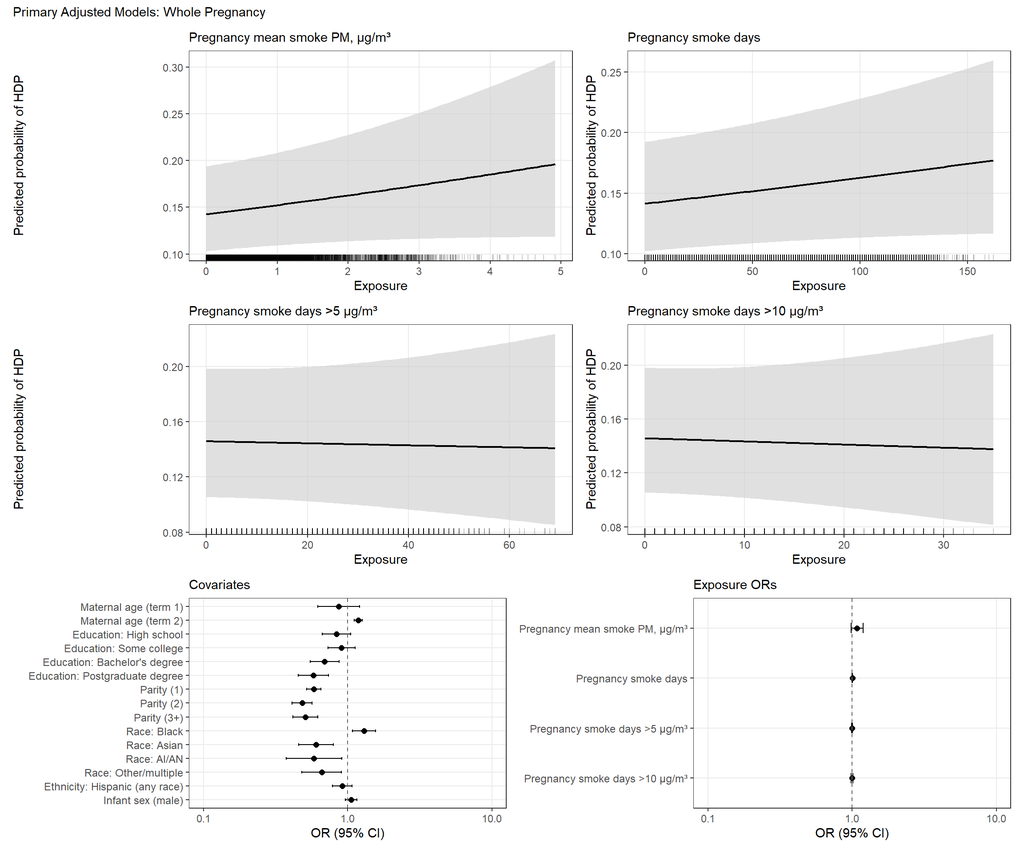

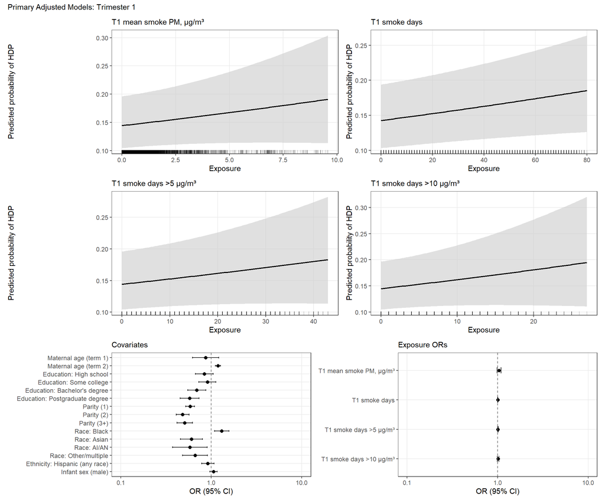

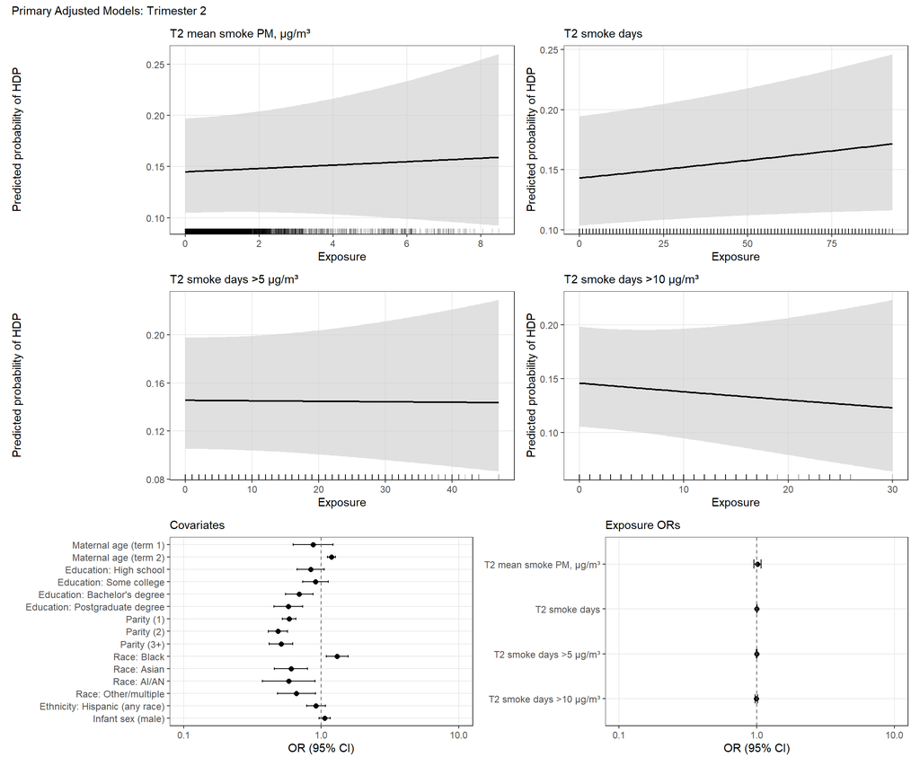

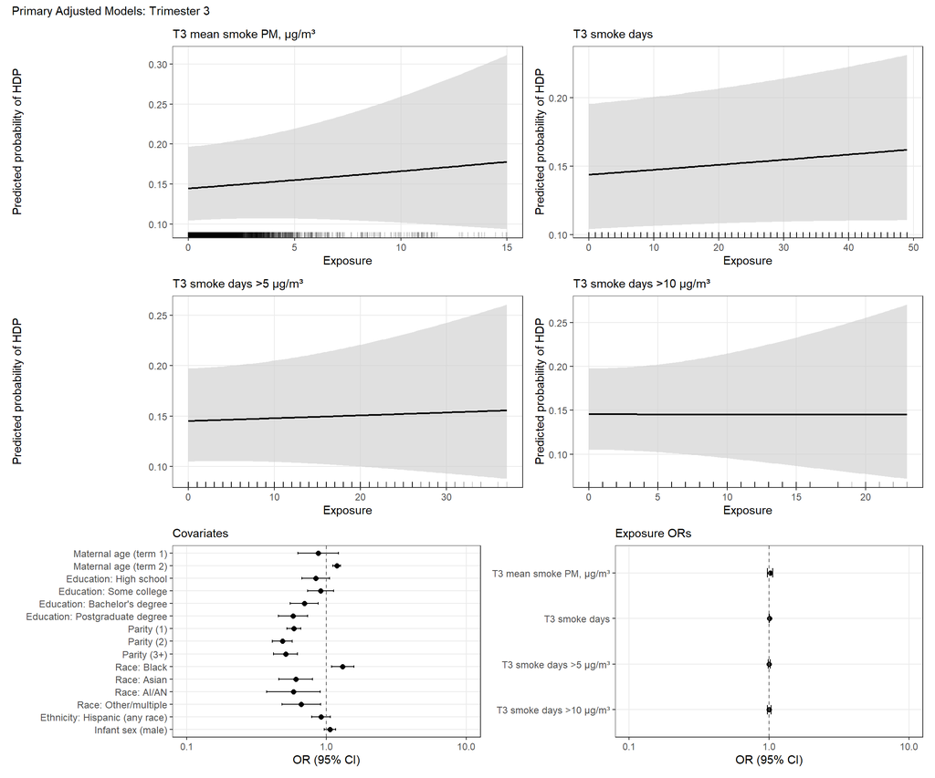

## 1.3 Fully Adjusted

From AP: “Extended models will be additionally adjusted for covariates selected based on availability of harmonized variables across cohorts, including household size-adjusted income (or neighborhood deprivation index), maternal pre-pregnancy BMI, history of chronic hypertension, history of pre-eclampsia, pre-pregnancy diabetes, prenatal smoking.”

- Model: Same parameters as primary adjusted model for exposure, outcome, cohort random intercept, handling missing data, and model optimization.
- Covariates: Maternal age (splined), secular trend (year splines), census macro region, tobacco use, alcohol consumption, tract-level poverty, pre-pregnancy BMI, birthing parent educational attainment, parity, race/ethnicity, infant sex

Extended Adjusted Model: preg_smoke_days

| Term | OR | 95% CI Low | 95% CI High | P-value |
| --- | --- | --- | --- | --- |
| Intercept | 0.093 | 0.053 | 0.164 | 0.0000 |
| preg_smoke_days (exposure) | 0.995 | 0.992 | 0.998 | 0.0015 |
| Maternal age (term 1) | 0.777 | 0.554 | 1.091 | 0.1457 |
| Maternal age (term 2) | 1.149 | 1.077 | 1.227 | 0.0000 |
| Year (term 1) | 0.946 | 0.675 | 1.326 | 0.7472 |
| Year (term 2) | 0.969 | 0.665 | 1.412 | 0.8696 |
| Year (term 3) | 1.378 | 0.958 | 1.982 | 0.0837 |
| Smoking | 1.100 | 0.915 | 1.322 | 0.3110 |
| Alcohol consumption | 0.938 | 0.810 | 1.086 | 0.3920 |
| Spring conception | 1.073 | 0.931 | 1.235 | 0.3308 |
| Summer conception | 0.970 | 0.852 | 1.106 | 0.6530 |
| Winter conception | 1.103 | 0.959 | 1.269 | 0.1706 |
| Midwest | 1.040 | 0.908 | 1.192 | 0.5699 |
| South | 1.117 | 0.968 | 1.288 | 0.1292 |
| West | 1.022 | 0.894 | 1.170 | 0.7466 |
| Tract-level poverty | 0.998 | 0.994 | 1.002 | 0.3134 |
| BMI: Normal weight | 1.237 | 0.805 | 1.901 | 0.3307 |
| BMI: Overweight | 1.899 | 1.229 | 2.934 | 0.0040 |
| BMI: Obese | 3.216 | 2.091 | 4.946 | 0.0000 |
| Education: High school | 0.837 | 0.665 | 1.054 | 0.1303 |
| Education: Some college | 0.931 | 0.750 | 1.156 | 0.5173 |
| Education: Bachelor’s degree | 0.795 | 0.630 | 1.003 | 0.0529 |
| Education: Postgraduate degree | 0.703 | 0.550 | 0.898 | 0.0049 |
| Parity (1) | 0.569 | 0.508 | 0.637 | 0.0000 |
| Parity (2) | 0.473 | 0.402 | 0.557 | 0.0000 |
| Parity (3+) | 0.477 | 0.391 | 0.581 | 0.0000 |
| Race: Black | 1.171 | 0.974 | 1.408 | 0.0928 |
| Race: Asian | 0.641 | 0.483 | 0.851 | 0.0021 |
| Race: AI/AN | 0.536 | 0.342 | 0.839 | 0.0064 |
| Race: Other/multiple | 0.638 | 0.464 | 0.879 | 0.0059 |
| Ethnicity: Hispanic (any race) | 0.798 | 0.680 | 0.936 | 0.0056 |
| Infant sex (male) | 1.057 | 0.963 | 1.160 | 0.2406 |

Extended Adjusted Model: T1_smoke_days

| Term | OR | 95% CI Low | 95% CI High | P-value |
| --- | --- | --- | --- | --- |
| Intercept | 0.086 | 0.049 | 0.150 | 0.0000 |
| T1_smoke_days (exposure) | 1.003 | 0.999 | 1.008 | 0.1580 |
| Maternal age (term 1) | 0.773 | 0.551 | 1.086 | 0.1374 |
| Maternal age (term 2) | 1.153 | 1.081 | 1.231 | 0.0000 |
| Year (term 1) | 1.233 | 0.900 | 1.688 | 0.1926 |
| Year (term 2) | 1.060 | 0.733 | 1.534 | 0.7564 |
| Year (term 3) | 0.980 | 0.707 | 1.358 | 0.9018 |
| Smoking | 1.105 | 0.920 | 1.329 | 0.2857 |
| Alcohol consumption | 0.940 | 0.812 | 1.088 | 0.4067 |
| Spring conception | 0.961 | 0.836 | 1.104 | 0.5740 |
| Summer conception | 0.899 | 0.771 | 1.049 | 0.1764 |
| Winter conception | 1.021 | 0.895 | 1.163 | 0.7597 |
| Midwest | 1.036 | 0.904 | 1.187 | 0.6112 |
| South | 1.115 | 0.967 | 1.286 | 0.1351 |
| West | 1.023 | 0.894 | 1.170 | 0.7429 |
| Tract-level poverty | 0.998 | 0.994 | 1.002 | 0.2799 |
| BMI: Normal weight | 1.238 | 0.806 | 1.901 | 0.3277 |
| BMI: Overweight | 1.898 | 1.229 | 2.930 | 0.0040 |
| BMI: Obese | 3.227 | 2.101 | 4.958 | 0.0000 |
| Education: High school | 0.836 | 0.664 | 1.052 | 0.1260 |
| Education: Some college | 0.932 | 0.751 | 1.158 | 0.5263 |
| Education: Bachelor’s degree | 0.793 | 0.628 | 1.000 | 0.0503 |
| Education: Postgraduate degree | 0.703 | 0.550 | 0.898 | 0.0048 |
| Parity (1) | 0.564 | 0.503 | 0.632 | 0.0000 |
| Parity (2) | 0.470 | 0.399 | 0.553 | 0.0000 |
| Parity (3+) | 0.472 | 0.387 | 0.575 | 0.0000 |
| Race: Black | 1.171 | 0.974 | 1.408 | 0.0927 |
| Race: Asian | 0.650 | 0.490 | 0.862 | 0.0028 |
| Race: AI/AN | 0.543 | 0.347 | 0.849 | 0.0075 |
| Race: Other/multiple | 0.645 | 0.469 | 0.888 | 0.0072 |
| Ethnicity: Hispanic (any race) | 0.809 | 0.689 | 0.949 | 0.0092 |
| Infant sex (male) | 1.054 | 0.961 | 1.157 | 0.2620 |

Extended Adjusted Model: T2_smoke_days

| Term | OR | 95% CI Low | 95% CI High | P-value |
| --- | --- | --- | --- | --- |
| Intercept | 0.087 | 0.050 | 0.151 | 0.0000 |
| T2_smoke_days (exposure) | 0.998 | 0.994 | 1.002 | 0.2505 |
| Maternal age (term 1) | 0.777 | 0.553 | 1.090 | 0.1438 |
| Maternal age (term 2) | 1.151 | 1.079 | 1.229 | 0.0000 |
| Year (term 1) | 1.127 | 0.820 | 1.549 | 0.4615 |
| Year (term 2) | 1.034 | 0.713 | 1.498 | 0.8600 |
| Year (term 3) | 1.096 | 0.787 | 1.527 | 0.5869 |
| Smoking | 1.103 | 0.917 | 1.325 | 0.2981 |
| Alcohol consumption | 0.938 | 0.810 | 1.086 | 0.3905 |
| Spring conception | 1.040 | 0.890 | 1.215 | 0.6251 |
| Summer conception | 0.953 | 0.837 | 1.085 | 0.4662 |
| Winter conception | 1.050 | 0.911 | 1.211 | 0.4998 |
| Midwest | 1.038 | 0.905 | 1.189 | 0.5967 |
| South | 1.116 | 0.967 | 1.287 | 0.1331 |
| West | 1.023 | 0.894 | 1.170 | 0.7436 |
| Tract-level poverty | 0.998 | 0.994 | 1.002 | 0.2919 |
| BMI: Normal weight | 1.237 | 0.806 | 1.900 | 0.3295 |
| BMI: Overweight | 1.897 | 1.229 | 2.929 | 0.0040 |
| BMI: Obese | 3.222 | 2.097 | 4.951 | 0.0000 |
| Education: High school | 0.837 | 0.665 | 1.054 | 0.1304 |
| Education: Some college | 0.933 | 0.751 | 1.159 | 0.5301 |
| Education: Bachelor’s degree | 0.794 | 0.629 | 1.002 | 0.0515 |
| Education: Postgraduate degree | 0.703 | 0.551 | 0.898 | 0.0048 |
| Parity (1) | 0.565 | 0.504 | 0.632 | 0.0000 |
| Parity (2) | 0.471 | 0.400 | 0.554 | 0.0000 |
| Parity (3+) | 0.473 | 0.388 | 0.577 | 0.0000 |
| Race: Black | 1.171 | 0.974 | 1.408 | 0.0920 |
| Race: Asian | 0.646 | 0.487 | 0.857 | 0.0025 |
| Race: AI/AN | 0.542 | 0.346 | 0.848 | 0.0073 |
| Race: Other/multiple | 0.643 | 0.467 | 0.885 | 0.0067 |
| Ethnicity: Hispanic (any race) | 0.805 | 0.686 | 0.945 | 0.0079 |
| Infant sex (male) | 1.056 | 0.963 | 1.159 | 0.2467 |

Extended Adjusted Model: T3_smoke_days

| Term | OR | 95% CI Low | 95% CI High | P-value |
| --- | --- | --- | --- | --- |
| Intercept | 0.088 | 0.051 | 0.155 | 0.0000 |
| T3_smoke_days (exposure) | 0.996 | 0.989 | 1.003 | 0.2375 |
| Maternal age (term 1) | 0.774 | 0.552 | 1.087 | 0.1388 |
| Maternal age (term 2) | 1.152 | 1.080 | 1.230 | 0.0000 |
| Year (term 1) | 1.148 | 0.841 | 1.568 | 0.3851 |
| Year (term 2) | 1.032 | 0.713 | 1.496 | 0.8659 |
| Year (term 3) | 1.075 | 0.778 | 1.485 | 0.6603 |
| Smoking | 1.105 | 0.919 | 1.328 | 0.2872 |
| Alcohol consumption | 0.940 | 0.812 | 1.088 | 0.4049 |
| Spring conception | 0.967 | 0.843 | 1.111 | 0.6378 |
| Summer conception | 0.927 | 0.808 | 1.064 | 0.2836 |
| Winter conception | 1.043 | 0.909 | 1.196 | 0.5516 |
| Midwest | 1.038 | 0.906 | 1.190 | 0.5927 |
| South | 1.116 | 0.967 | 1.287 | 0.1325 |
| West | 1.023 | 0.894 | 1.170 | 0.7399 |
| Tract-level poverty | 0.998 | 0.994 | 1.002 | 0.2903 |
| BMI: Normal weight | 1.239 | 0.807 | 1.903 | 0.3264 |
| BMI: Overweight | 1.900 | 1.230 | 2.933 | 0.0039 |
| BMI: Obese | 3.225 | 2.099 | 4.956 | 0.0000 |
| Education: High school | 0.835 | 0.663 | 1.051 | 0.1238 |
| Education: Some college | 0.930 | 0.749 | 1.155 | 0.5139 |
| Education: Bachelor’s degree | 0.792 | 0.627 | 0.999 | 0.0488 |
| Education: Postgraduate degree | 0.702 | 0.549 | 0.896 | 0.0046 |
| Parity (1) | 0.566 | 0.505 | 0.634 | 0.0000 |
| Parity (2) | 0.471 | 0.400 | 0.555 | 0.0000 |
| Parity (3+) | 0.473 | 0.388 | 0.576 | 0.0000 |
| Race: Black | 1.171 | 0.974 | 1.408 | 0.0925 |
| Race: Asian | 0.648 | 0.489 | 0.859 | 0.0026 |
| Race: AI/AN | 0.541 | 0.346 | 0.846 | 0.0072 |
| Race: Other/multiple | 0.643 | 0.467 | 0.886 | 0.0069 |
| Ethnicity: Hispanic (any race) | 0.805 | 0.686 | 0.945 | 0.0080 |
| Infant sex (male) | 1.055 | 0.962 | 1.158 | 0.2543 |

Extended Adjusted Model: preg_smoke_days_over5

| Term | OR | 95% CI Low | 95% CI High | P-value |
| --- | --- | --- | --- | --- |
| Intercept | 0.090 | 0.051 | 0.157 | 0.0000 |
| preg_smoke_days_over5 (exposure) | 0.990 | 0.983 | 0.997 | 0.0073 |
| Maternal age (term 1) | 0.777 | 0.554 | 1.090 | 0.1445 |
| Maternal age (term 2) | 1.151 | 1.079 | 1.229 | 0.0000 |
| Year (term 1) | 1.076 | 0.785 | 1.476 | 0.6480 |
| Year (term 2) | 1.028 | 0.709 | 1.489 | 0.8856 |
| Year (term 3) | 1.162 | 0.838 | 1.613 | 0.3681 |
| Smoking | 1.102 | 0.916 | 1.324 | 0.3027 |
| Alcohol consumption | 0.937 | 0.809 | 1.084 | 0.3780 |
| Spring conception | 1.029 | 0.899 | 1.178 | 0.6819 |
| Summer conception | 0.962 | 0.845 | 1.096 | 0.5644 |
| Winter conception | 1.054 | 0.922 | 1.204 | 0.4415 |
| Midwest | 1.038 | 0.905 | 1.190 | 0.5938 |
| South | 1.115 | 0.967 | 1.286 | 0.1354 |
| West | 1.021 | 0.892 | 1.168 | 0.7612 |
| Tract-level poverty | 0.998 | 0.994 | 1.002 | 0.2940 |
| BMI: Normal weight | 1.240 | 0.807 | 1.906 | 0.3243 |
| BMI: Overweight | 1.902 | 1.232 | 2.938 | 0.0039 |
| BMI: Obese | 3.227 | 2.099 | 4.961 | 0.0000 |
| Education: High school | 0.838 | 0.666 | 1.055 | 0.1323 |
| Education: Some college | 0.932 | 0.751 | 1.158 | 0.5254 |
| Education: Bachelor’s degree | 0.794 | 0.629 | 1.002 | 0.0518 |
| Education: Postgraduate degree | 0.703 | 0.551 | 0.898 | 0.0048 |
| Parity (1) | 0.567 | 0.506 | 0.636 | 0.0000 |
| Parity (2) | 0.473 | 0.401 | 0.556 | 0.0000 |
| Parity (3+) | 0.475 | 0.390 | 0.579 | 0.0000 |
| Race: Black | 1.179 | 0.981 | 1.418 | 0.0791 |
| Race: Asian | 0.645 | 0.486 | 0.855 | 0.0023 |
| Race: AI/AN | 0.542 | 0.346 | 0.848 | 0.0074 |
| Race: Other/multiple | 0.642 | 0.467 | 0.884 | 0.0067 |
| Ethnicity: Hispanic (any race) | 0.804 | 0.685 | 0.943 | 0.0073 |
| Infant sex (male) | 1.056 | 0.962 | 1.158 | 0.2524 |

Extended Adjusted Model: T1_smoke_days_over5

| Term | OR | 95% CI Low | 95% CI High | P-value |
| --- | --- | --- | --- | --- |
| Intercept | 0.086 | 0.049 | 0.151 | 0.0000 |
| T1_smoke_days_over5 (exposure) | 1.005 | 0.994 | 1.016 | 0.3920 |
| Maternal age (term 1) | 0.775 | 0.552 | 1.088 | 0.1414 |
| Maternal age (term 2) | 1.152 | 1.080 | 1.230 | 0.0000 |
| Year (term 1) | 1.193 | 0.875 | 1.627 | 0.2640 |
| Year (term 2) | 1.047 | 0.723 | 1.515 | 0.8081 |
| Year (term 3) | 1.021 | 0.742 | 1.405 | 0.8997 |
| Smoking | 1.105 | 0.919 | 1.329 | 0.2863 |
| Alcohol consumption | 0.940 | 0.812 | 1.088 | 0.4015 |
| Spring conception | 0.979 | 0.856 | 1.121 | 0.7597 |
| Summer conception | 0.931 | 0.809 | 1.072 | 0.3231 |
| Winter conception | 1.018 | 0.893 | 1.160 | 0.7879 |
| Midwest | 1.037 | 0.905 | 1.188 | 0.6019 |
| South | 1.115 | 0.967 | 1.286 | 0.1340 |
| West | 1.023 | 0.894 | 1.170 | 0.7402 |
| Tract-level poverty | 0.998 | 0.994 | 1.002 | 0.2856 |
| BMI: Normal weight | 1.239 | 0.807 | 1.902 | 0.3264 |
| BMI: Overweight | 1.899 | 1.230 | 2.931 | 0.0040 |
| BMI: Obese | 3.227 | 2.101 | 4.957 | 0.0000 |
| Education: High school | 0.836 | 0.664 | 1.052 | 0.1263 |
| Education: Some college | 0.932 | 0.750 | 1.157 | 0.5224 |
| Education: Bachelor’s degree | 0.792 | 0.628 | 1.000 | 0.0499 |
| Education: Postgraduate degree | 0.702 | 0.550 | 0.897 | 0.0047 |
| Parity (1) | 0.564 | 0.503 | 0.632 | 0.0000 |
| Parity (2) | 0.470 | 0.400 | 0.554 | 0.0000 |
| Parity (3+) | 0.472 | 0.387 | 0.575 | 0.0000 |
| Race: Black | 1.170 | 0.973 | 1.407 | 0.0942 |
| Race: Asian | 0.649 | 0.489 | 0.860 | 0.0027 |
| Race: AI/AN | 0.542 | 0.347 | 0.849 | 0.0074 |
| Race: Other/multiple | 0.645 | 0.468 | 0.887 | 0.0071 |
| Ethnicity: Hispanic (any race) | 0.807 | 0.688 | 0.947 | 0.0087 |
| Infant sex (male) | 1.056 | 0.962 | 1.158 | 0.2532 |

Extended Adjusted Model: T2_smoke_days_over5

| Term | OR | 95% CI Low | 95% CI High | P-value |
| --- | --- | --- | --- | --- |
| Intercept | 0.087 | 0.049 | 0.151 | 0.0000 |
| T2_smoke_days_over5 (exposure) | 0.990 | 0.979 | 1.001 | 0.0697 |
| Maternal age (term 1) | 0.776 | 0.553 | 1.089 | 0.1424 |
| Maternal age (term 2) | 1.152 | 1.079 | 1.229 | 0.0000 |
| Year (term 1) | 1.134 | 0.830 | 1.548 | 0.4298 |
| Year (term 2) | 1.038 | 0.717 | 1.504 | 0.8421 |
| Year (term 3) | 1.087 | 0.789 | 1.499 | 0.6092 |
| Smoking | 1.104 | 0.919 | 1.328 | 0.2897 |
| Alcohol consumption | 0.937 | 0.810 | 1.085 | 0.3848 |
| Spring conception | 1.045 | 0.905 | 1.207 | 0.5461 |
| Summer conception | 0.954 | 0.838 | 1.087 | 0.4816 |
| Winter conception | 1.053 | 0.919 | 1.207 | 0.4552 |
| Midwest | 1.036 | 0.904 | 1.188 | 0.6095 |
| South | 1.114 | 0.966 | 1.285 | 0.1384 |
| West | 1.022 | 0.893 | 1.169 | 0.7517 |
| Tract-level poverty | 0.998 | 0.994 | 1.002 | 0.2870 |
| BMI: Normal weight | 1.239 | 0.807 | 1.902 | 0.3268 |
| BMI: Overweight | 1.898 | 1.229 | 2.929 | 0.0040 |
| BMI: Obese | 3.225 | 2.099 | 4.955 | 0.0000 |
| Education: High school | 0.838 | 0.666 | 1.054 | 0.1311 |
| Education: Some college | 0.933 | 0.751 | 1.158 | 0.5280 |
| Education: Bachelor’s degree | 0.794 | 0.629 | 1.002 | 0.0515 |
| Education: Postgraduate degree | 0.703 | 0.551 | 0.898 | 0.0048 |
| Parity (1) | 0.565 | 0.504 | 0.633 | 0.0000 |
| Parity (2) | 0.471 | 0.400 | 0.554 | 0.0000 |
| Parity (3+) | 0.474 | 0.389 | 0.578 | 0.0000 |
| Race: Black | 1.176 | 0.978 | 1.414 | 0.0846 |
| Race: Asian | 0.647 | 0.488 | 0.858 | 0.0025 |
| Race: AI/AN | 0.543 | 0.347 | 0.850 | 0.0075 |
| Race: Other/multiple | 0.643 | 0.467 | 0.885 | 0.0067 |
| Ethnicity: Hispanic (any race) | 0.806 | 0.687 | 0.946 | 0.0082 |
| Infant sex (male) | 1.056 | 0.962 | 1.158 | 0.2507 |

Extended Adjusted Model: T3_smoke_days_over5

| Term | OR | 95% CI Low | 95% CI High | P-value |
| --- | --- | --- | --- | --- |
| Intercept | 0.088 | 0.050 | 0.153 | 0.0000 |
| T3_smoke_days_over5 (exposure) | 0.991 | 0.974 | 1.007 | 0.2757 |
| Maternal age (term 1) | 0.775 | 0.553 | 1.088 | 0.1414 |
| Maternal age (term 2) | 1.153 | 1.080 | 1.230 | 0.0000 |
| Year (term 1) | 1.158 | 0.849 | 1.580 | 0.3540 |
| Year (term 2) | 1.040 | 0.718 | 1.505 | 0.8365 |
| Year (term 3) | 1.060 | 0.770 | 1.460 | 0.7202 |
| Smoking | 1.105 | 0.919 | 1.328 | 0.2883 |
| Alcohol consumption | 0.939 | 0.811 | 1.087 | 0.3958 |
| Spring conception | 0.977 | 0.854 | 1.118 | 0.7368 |
| Summer conception | 0.938 | 0.821 | 1.071 | 0.3436 |
| Winter conception | 1.031 | 0.902 | 1.177 | 0.6566 |
| Midwest | 1.038 | 0.906 | 1.190 | 0.5888 |
| South | 1.116 | 0.967 | 1.287 | 0.1326 |
| West | 1.023 | 0.895 | 1.171 | 0.7368 |
| Tract-level poverty | 0.998 | 0.994 | 1.002 | 0.2903 |
| BMI: Normal weight | 1.240 | 0.807 | 1.904 | 0.3250 |
| BMI: Overweight | 1.900 | 1.231 | 2.934 | 0.0039 |
| BMI: Obese | 3.228 | 2.101 | 4.960 | 0.0000 |
| Education: High school | 0.835 | 0.664 | 1.051 | 0.1253 |
| Education: Some college | 0.931 | 0.750 | 1.157 | 0.5197 |
| Education: Bachelor’s degree | 0.792 | 0.627 | 0.999 | 0.0490 |
| Education: Postgraduate degree | 0.702 | 0.549 | 0.896 | 0.0046 |
| Parity (1) | 0.566 | 0.505 | 0.634 | 0.0000 |
| Parity (2) | 0.471 | 0.400 | 0.555 | 0.0000 |
| Parity (3+) | 0.472 | 0.388 | 0.576 | 0.0000 |
| Race: Black | 1.173 | 0.975 | 1.410 | 0.0903 |
| Race: Asian | 0.648 | 0.489 | 0.859 | 0.0026 |
| Race: AI/AN | 0.542 | 0.347 | 0.849 | 0.0074 |
| Race: Other/multiple | 0.644 | 0.468 | 0.887 | 0.0070 |
| Ethnicity: Hispanic (any race) | 0.806 | 0.687 | 0.945 | 0.0081 |
| Infant sex (male) | 1.055 | 0.962 | 1.158 | 0.2545 |

Extended Adjusted Model: preg_smoke_days_over10

| Term | OR | 95% CI Low | 95% CI High | P-value |
| --- | --- | --- | --- | --- |
| Intercept | 0.088 | 0.050 | 0.153 | 0.0000 |
| preg_smoke_days_over10 (exposure) | 0.985 | 0.971 | 0.999 | 0.0335 |
| Maternal age (term 1) | 0.777 | 0.554 | 1.091 | 0.1456 |
| Maternal age (term 2) | 1.151 | 1.079 | 1.229 | 0.0000 |
| Year (term 1) | 1.174 | 0.863 | 1.598 | 0.3074 |
| Year (term 2) | 1.018 | 0.703 | 1.474 | 0.9248 |
| Year (term 3) | 1.057 | 0.769 | 1.451 | 0.7340 |
| Smoking | 1.103 | 0.918 | 1.327 | 0.2949 |
| Alcohol consumption | 0.935 | 0.808 | 1.083 | 0.3696 |
| Spring conception | 1.010 | 0.884 | 1.154 | 0.8855 |
| Summer conception | 0.959 | 0.842 | 1.092 | 0.5252 |
| Winter conception | 1.035 | 0.907 | 1.181 | 0.6093 |
| Midwest | 1.036 | 0.904 | 1.187 | 0.6133 |
| South | 1.114 | 0.966 | 1.285 | 0.1387 |
| West | 1.022 | 0.893 | 1.169 | 0.7519 |
| Tract-level poverty | 0.998 | 0.994 | 1.002 | 0.2933 |
| BMI: Normal weight | 1.242 | 0.809 | 1.909 | 0.3210 |
| BMI: Overweight | 1.904 | 1.232 | 2.940 | 0.0039 |
| BMI: Obese | 3.232 | 2.102 | 4.968 | 0.0000 |
| Education: High school | 0.838 | 0.666 | 1.055 | 0.1317 |
| Education: Some college | 0.934 | 0.752 | 1.159 | 0.5338 |
| Education: Bachelor’s degree | 0.794 | 0.629 | 1.002 | 0.0516 |
| Education: Postgraduate degree | 0.704 | 0.551 | 0.899 | 0.0049 |
| Parity (1) | 0.566 | 0.505 | 0.634 | 0.0000 |
| Parity (2) | 0.472 | 0.401 | 0.555 | 0.0000 |
| Parity (3+) | 0.474 | 0.389 | 0.577 | 0.0000 |
| Race: Black | 1.177 | 0.979 | 1.415 | 0.0832 |
| Race: Asian | 0.646 | 0.487 | 0.857 | 0.0024 |
| Race: AI/AN | 0.546 | 0.349 | 0.854 | 0.0081 |
| Race: Other/multiple | 0.645 | 0.468 | 0.888 | 0.0071 |
| Ethnicity: Hispanic (any race) | 0.805 | 0.686 | 0.945 | 0.0080 |
| Infant sex (male) | 1.055 | 0.962 | 1.158 | 0.2553 |

Extended Adjusted Model: T1_smoke_days_over10

| Term | OR | 95% CI Low | 95% CI High | P-value |
| --- | --- | --- | --- | --- |
| Intercept | 0.086 | 0.049 | 0.151 | 0.0000 |
| T1_smoke_days_over10 (exposure) | 1.008 | 0.986 | 1.031 | 0.4721 |
| Maternal age (term 1) | 0.776 | 0.553 | 1.090 | 0.1436 |
| Maternal age (term 2) | 1.152 | 1.080 | 1.230 | 0.0000 |
| Year (term 1) | 1.178 | 0.865 | 1.605 | 0.2987 |
| Year (term 2) | 1.051 | 0.726 | 1.521 | 0.7930 |
| Year (term 3) | 1.035 | 0.753 | 1.422 | 0.8318 |
| Smoking | 1.105 | 0.919 | 1.328 | 0.2876 |
| Alcohol consumption | 0.940 | 0.812 | 1.088 | 0.4018 |
| Spring conception | 0.985 | 0.862 | 1.125 | 0.8233 |
| Summer conception | 0.941 | 0.822 | 1.077 | 0.3761 |
| Winter conception | 1.017 | 0.892 | 1.159 | 0.8023 |
| Midwest | 1.037 | 0.905 | 1.189 | 0.5967 |
| South | 1.115 | 0.967 | 1.286 | 0.1331 |
| West | 1.023 | 0.894 | 1.170 | 0.7420 |
| Tract-level poverty | 0.998 | 0.994 | 1.002 | 0.2859 |
| BMI: Normal weight | 1.239 | 0.807 | 1.903 | 0.3261 |
| BMI: Overweight | 1.899 | 1.230 | 2.932 | 0.0039 |
| BMI: Obese | 3.227 | 2.101 | 4.958 | 0.0000 |
| Education: High school | 0.836 | 0.664 | 1.052 | 0.1263 |
| Education: Some college | 0.931 | 0.750 | 1.156 | 0.5194 |
| Education: Bachelor’s degree | 0.792 | 0.628 | 0.999 | 0.0495 |
| Education: Postgraduate degree | 0.702 | 0.550 | 0.897 | 0.0046 |
| Parity (1) | 0.564 | 0.504 | 0.632 | 0.0000 |
| Parity (2) | 0.470 | 0.400 | 0.554 | 0.0000 |
| Parity (3+) | 0.472 | 0.388 | 0.576 | 0.0000 |
| Race: Black | 1.170 | 0.973 | 1.406 | 0.0948 |
| Race: Asian | 0.648 | 0.489 | 0.860 | 0.0026 |
| Race: AI/AN | 0.542 | 0.347 | 0.848 | 0.0073 |
| Race: Other/multiple | 0.644 | 0.468 | 0.887 | 0.0070 |
| Ethnicity: Hispanic (any race) | 0.807 | 0.688 | 0.947 | 0.0086 |
| Infant sex (male) | 1.056 | 0.962 | 1.158 | 0.2508 |

Extended Adjusted Model: T2_smoke_days_over10

| Term | OR | 95% CI Low | 95% CI High | P-value |
| --- | --- | --- | --- | --- |
| Intercept | 0.086 | 0.049 | 0.151 | 0.0000 |
| T2_smoke_days_over10 (exposure) | 0.979 | 0.958 | 1.001 | 0.0625 |
| Maternal age (term 1) | 0.776 | 0.553 | 1.090 | 0.1434 |
| Maternal age (term 2) | 1.151 | 1.079 | 1.229 | 0.0000 |
| Year (term 1) | 1.176 | 0.864 | 1.601 | 0.3037 |
| Year (term 2) | 1.031 | 0.712 | 1.492 | 0.8729 |
| Year (term 3) | 1.047 | 0.762 | 1.437 | 0.7774 |
| Smoking | 1.106 | 0.920 | 1.330 | 0.2819 |
| Alcohol consumption | 0.937 | 0.810 | 1.085 | 0.3828 |
| Spring conception | 1.029 | 0.896 | 1.180 | 0.6891 |
| Summer conception | 0.954 | 0.838 | 1.087 | 0.4789 |
| Winter conception | 1.039 | 0.910 | 1.187 | 0.5688 |
| Midwest | 1.035 | 0.903 | 1.187 | 0.6172 |
| South | 1.113 | 0.965 | 1.284 | 0.1418 |
| West | 1.022 | 0.893 | 1.169 | 0.7550 |
| Tract-level poverty | 0.998 | 0.994 | 1.002 | 0.2877 |
| BMI: Normal weight | 1.241 | 0.808 | 1.906 | 0.3225 |
| BMI: Overweight | 1.900 | 1.231 | 2.933 | 0.0039 |
| BMI: Obese | 3.230 | 2.102 | 4.964 | 0.0000 |
| Education: High school | 0.837 | 0.665 | 1.053 | 0.1289 |
| Education: Some college | 0.932 | 0.751 | 1.158 | 0.5252 |
| Education: Bachelor’s degree | 0.793 | 0.628 | 1.001 | 0.0506 |
| Education: Postgraduate degree | 0.703 | 0.550 | 0.897 | 0.0047 |
| Parity (1) | 0.565 | 0.504 | 0.633 | 0.0000 |
| Parity (2) | 0.471 | 0.400 | 0.554 | 0.0000 |
| Parity (3+) | 0.474 | 0.389 | 0.577 | 0.0000 |
| Race: Black | 1.174 | 0.977 | 1.411 | 0.0877 |
| Race: Asian | 0.648 | 0.488 | 0.859 | 0.0026 |
| Race: AI/AN | 0.545 | 0.348 | 0.853 | 0.0079 |
| Race: Other/multiple | 0.643 | 0.467 | 0.886 | 0.0069 |
| Ethnicity: Hispanic (any race) | 0.806 | 0.687 | 0.946 | 0.0082 |
| Infant sex (male) | 1.056 | 0.962 | 1.158 | 0.2526 |

Extended Adjusted Model: T3_smoke_days_over10

| Term | OR | 95% CI Low | 95% CI High | P-value |
| --- | --- | --- | --- | --- |
| Intercept | 0.087 | 0.050 | 0.152 | 0.0000 |
| T3_smoke_days_over10 (exposure) | 0.984 | 0.954 | 1.016 | 0.3341 |
| Maternal age (term 1) | 0.777 | 0.553 | 1.090 | 0.1442 |
| Maternal age (term 2) | 1.152 | 1.080 | 1.230 | 0.0000 |
| Year (term 1) | 1.177 | 0.864 | 1.603 | 0.3009 |
| Year (term 2) | 1.039 | 0.718 | 1.505 | 0.8380 |
| Year (term 3) | 1.042 | 0.758 | 1.431 | 0.8004 |
| Smoking | 1.105 | 0.919 | 1.328 | 0.2884 |
| Alcohol consumption | 0.938 | 0.811 | 1.086 | 0.3918 |
| Spring conception | 0.984 | 0.861 | 1.124 | 0.8115 |
| Summer conception | 0.946 | 0.830 | 1.078 | 0.4033 |
| Winter conception | 1.025 | 0.899 | 1.170 | 0.7089 |
| Midwest | 1.038 | 0.906 | 1.190 | 0.5918 |
| South | 1.116 | 0.967 | 1.287 | 0.1322 |
| West | 1.024 | 0.895 | 1.171 | 0.7350 |
| Tract-level poverty | 0.998 | 0.994 | 1.002 | 0.2888 |
| BMI: Normal weight | 1.240 | 0.807 | 1.904 | 0.3252 |
| BMI: Overweight | 1.900 | 1.231 | 2.934 | 0.0039 |
| BMI: Obese | 3.227 | 2.100 | 4.959 | 0.0000 |
| Education: High school | 0.836 | 0.664 | 1.052 | 0.1256 |
| Education: Some college | 0.931 | 0.750 | 1.157 | 0.5201 |
| Education: Bachelor’s degree | 0.792 | 0.627 | 0.999 | 0.0491 |
| Education: Postgraduate degree | 0.702 | 0.550 | 0.897 | 0.0046 |
| Parity (1) | 0.565 | 0.504 | 0.633 | 0.0000 |
| Parity (2) | 0.471 | 0.400 | 0.554 | 0.0000 |
| Parity (3+) | 0.472 | 0.388 | 0.576 | 0.0000 |
| Race: Black | 1.173 | 0.975 | 1.410 | 0.0903 |
| Race: Asian | 0.648 | 0.488 | 0.859 | 0.0026 |
| Race: AI/AN | 0.543 | 0.347 | 0.849 | 0.0075 |
| Race: Other/multiple | 0.645 | 0.468 | 0.888 | 0.0071 |
| Ethnicity: Hispanic (any race) | 0.807 | 0.688 | 0.947 | 0.0085 |
| Infant sex (male) | 1.056 | 0.962 | 1.158 | 0.2515 |

Extended Adjusted Model: preg_smokePM_mean

| Term | OR | 95% CI Low | 95% CI High | P-value |
| --- | --- | --- | --- | --- |
| Intercept | 0.088 | 0.050 | 0.154 | 0.0000 |
| preg_smokePM_mean (exposure) | 0.917 | 0.814 | 1.033 | 0.1559 |
| Maternal age (term 1) | 0.776 | 0.553 | 1.089 | 0.1420 |
| Maternal age (term 2) | 1.152 | 1.079 | 1.229 | 0.0000 |
| Year (term 1) | 1.128 | 0.824 | 1.545 | 0.4521 |
| Year (term 2) | 1.026 | 0.708 | 1.487 | 0.8928 |
| Year (term 3) | 1.102 | 0.794 | 1.529 | 0.5627 |
| Smoking | 1.103 | 0.917 | 1.326 | 0.2983 |
| Alcohol consumption | 0.937 | 0.809 | 1.085 | 0.3817 |
| Spring conception | 1.009 | 0.882 | 1.154 | 0.8990 |
| Summer conception | 0.957 | 0.840 | 1.090 | 0.5083 |
| Winter conception | 1.035 | 0.906 | 1.182 | 0.6125 |
| Midwest | 1.038 | 0.905 | 1.189 | 0.5964 |
| South | 1.115 | 0.967 | 1.286 | 0.1336 |
| West | 1.022 | 0.894 | 1.170 | 0.7469 |
| Tract-level poverty | 0.998 | 0.994 | 1.002 | 0.2928 |
| BMI: Normal weight | 1.239 | 0.807 | 1.904 | 0.3264 |
| BMI: Overweight | 1.900 | 1.230 | 2.934 | 0.0039 |
| BMI: Obese | 3.226 | 2.099 | 4.958 | 0.0000 |
| Education: High school | 0.837 | 0.665 | 1.053 | 0.1290 |
| Education: Some college | 0.932 | 0.751 | 1.157 | 0.5233 |
| Education: Bachelor’s degree | 0.793 | 0.628 | 1.000 | 0.0505 |
| Education: Postgraduate degree | 0.703 | 0.550 | 0.898 | 0.0048 |
| Parity (1) | 0.566 | 0.505 | 0.634 | 0.0000 |
| Parity (2) | 0.472 | 0.401 | 0.555 | 0.0000 |
| Parity (3+) | 0.474 | 0.389 | 0.578 | 0.0000 |
| Race: Black | 1.174 | 0.976 | 1.411 | 0.0883 |
| Race: Asian | 0.646 | 0.487 | 0.857 | 0.0024 |
| Race: AI/AN | 0.543 | 0.347 | 0.850 | 0.0076 |
| Race: Other/multiple | 0.643 | 0.467 | 0.885 | 0.0068 |
| Ethnicity: Hispanic (any race) | 0.804 | 0.686 | 0.944 | 0.0076 |
| Infant sex (male) | 1.056 | 0.962 | 1.159 | 0.2495 |

Extended Adjusted Model: T1_smokePM_mean

| Term | OR | 95% CI Low | 95% CI High | P-value |
| --- | --- | --- | --- | --- |
| Intercept | 0.086 | 0.049 | 0.151 | 0.0000 |
| T1_smokePM_mean (exposure) | 1.013 | 0.955 | 1.075 | 0.6681 |
| Maternal age (term 1) | 0.776 | 0.553 | 1.089 | 0.1426 |
| Maternal age (term 2) | 1.152 | 1.080 | 1.230 | 0.0000 |
| Year (term 1) | 1.186 | 0.870 | 1.617 | 0.2807 |
| Year (term 2) | 1.049 | 0.725 | 1.519 | 0.7986 |
| Year (term 3) | 1.028 | 0.747 | 1.415 | 0.8637 |
| Smoking | 1.105 | 0.919 | 1.328 | 0.2894 |
| Alcohol consumption | 0.939 | 0.812 | 1.087 | 0.3997 |
| Spring conception | 0.985 | 0.861 | 1.127 | 0.8280 |
| Summer conception | 0.943 | 0.820 | 1.084 | 0.4087 |
| Winter conception | 1.017 | 0.892 | 1.159 | 0.8004 |
| Midwest | 1.037 | 0.905 | 1.189 | 0.5998 |
| South | 1.115 | 0.967 | 1.286 | 0.1335 |
| West | 1.023 | 0.894 | 1.170 | 0.7421 |
| Tract-level poverty | 0.998 | 0.994 | 1.002 | 0.2862 |
| BMI: Normal weight | 1.239 | 0.807 | 1.903 | 0.3260 |
| BMI: Overweight | 1.900 | 1.231 | 2.933 | 0.0039 |
| BMI: Obese | 3.227 | 2.101 | 4.957 | 0.0000 |
| Education: High school | 0.836 | 0.664 | 1.052 | 0.1270 |
| Education: Some college | 0.932 | 0.750 | 1.157 | 0.5227 |
| Education: Bachelor’s degree | 0.792 | 0.628 | 1.000 | 0.0499 |
| Education: Postgraduate degree | 0.702 | 0.550 | 0.897 | 0.0047 |
| Parity (1) | 0.564 | 0.504 | 0.632 | 0.0000 |
| Parity (2) | 0.470 | 0.400 | 0.554 | 0.0000 |
| Parity (3+) | 0.472 | 0.387 | 0.576 | 0.0000 |
| Race: Black | 1.171 | 0.974 | 1.407 | 0.0937 |
| Race: Asian | 0.648 | 0.489 | 0.860 | 0.0026 |
| Race: AI/AN | 0.542 | 0.347 | 0.848 | 0.0074 |
| Race: Other/multiple | 0.644 | 0.468 | 0.887 | 0.0070 |
| Ethnicity: Hispanic (any race) | 0.807 | 0.688 | 0.947 | 0.0086 |
| Infant sex (male) | 1.056 | 0.962 | 1.158 | 0.2514 |

Extended Adjusted Model: T2_smokePM_mean

| Term | OR | 95% CI Low | 95% CI High | P-value |
| --- | --- | --- | --- | --- |
| Intercept | 0.086 | 0.049 | 0.151 | 0.0000 |
| T2_smokePM_mean (exposure) | 0.943 | 0.878 | 1.013 | 0.1081 |
| Maternal age (term 1) | 0.776 | 0.553 | 1.089 | 0.1421 |
| Maternal age (term 2) | 1.152 | 1.079 | 1.229 | 0.0000 |
| Year (term 1) | 1.141 | 0.836 | 1.558 | 0.4056 |
| Year (term 2) | 1.033 | 0.713 | 1.496 | 0.8645 |
| Year (term 3) | 1.082 | 0.785 | 1.492 | 0.6302 |
| Smoking | 1.104 | 0.919 | 1.327 | 0.2909 |
| Alcohol consumption | 0.937 | 0.810 | 1.085 | 0.3847 |
| Spring conception | 1.037 | 0.898 | 1.196 | 0.6210 |
| Summer conception | 0.954 | 0.837 | 1.086 | 0.4738 |
| Winter conception | 1.047 | 0.915 | 1.200 | 0.5032 |
| Midwest | 1.036 | 0.904 | 1.187 | 0.6108 |
| South | 1.114 | 0.966 | 1.285 | 0.1379 |
| West | 1.022 | 0.894 | 1.170 | 0.7461 |
| Tract-level poverty | 0.998 | 0.994 | 1.002 | 0.2882 |
| BMI: Normal weight | 1.239 | 0.807 | 1.903 | 0.3266 |
| BMI: Overweight | 1.897 | 1.229 | 2.930 | 0.0040 |
| BMI: Obese | 3.225 | 2.099 | 4.956 | 0.0000 |
| Education: High school | 0.837 | 0.665 | 1.053 | 0.1294 |
| Education: Some college | 0.932 | 0.751 | 1.158 | 0.5270 |
| Education: Bachelor’s degree | 0.794 | 0.629 | 1.001 | 0.0514 |
| Education: Postgraduate degree | 0.703 | 0.550 | 0.898 | 0.0048 |
| Parity (1) | 0.565 | 0.504 | 0.633 | 0.0000 |
| Parity (2) | 0.471 | 0.400 | 0.554 | 0.0000 |
| Parity (3+) | 0.474 | 0.389 | 0.578 | 0.0000 |
| Race: Black | 1.173 | 0.976 | 1.410 | 0.0893 |
| Race: Asian | 0.647 | 0.488 | 0.858 | 0.0025 |
| Race: AI/AN | 0.543 | 0.347 | 0.850 | 0.0076 |
| Race: Other/multiple | 0.642 | 0.467 | 0.884 | 0.0067 |
| Ethnicity: Hispanic (any race) | 0.805 | 0.686 | 0.945 | 0.0080 |
| Infant sex (male) | 1.056 | 0.962 | 1.159 | 0.2496 |

Extended Adjusted Model: T3_smokePM_mean

| Term | OR | 95% CI Low | 95% CI High | P-value |
| --- | --- | --- | --- | --- |
| Intercept | 0.087 | 0.050 | 0.152 | 0.0000 |
| T3_smokePM_mean (exposure) | 0.978 | 0.931 | 1.029 | 0.3954 |
| Maternal age (term 1) | 0.776 | 0.553 | 1.089 | 0.1417 |
| Maternal age (term 2) | 1.152 | 1.080 | 1.230 | 0.0000 |
| Year (term 1) | 1.165 | 0.855 | 1.589 | 0.3334 |
| Year (term 2) | 1.039 | 0.718 | 1.505 | 0.8387 |
| Year (term 3) | 1.054 | 0.766 | 1.451 | 0.7479 |
| Smoking | 1.105 | 0.919 | 1.328 | 0.2887 |
| Alcohol consumption | 0.939 | 0.811 | 1.087 | 0.3951 |
| Spring conception | 0.980 | 0.857 | 1.121 | 0.7730 |
| Summer conception | 0.942 | 0.825 | 1.076 | 0.3770 |
| Winter conception | 1.028 | 0.900 | 1.174 | 0.6865 |
| Midwest | 1.038 | 0.906 | 1.190 | 0.5905 |
| South | 1.116 | 0.967 | 1.287 | 0.1321 |
| West | 1.023 | 0.895 | 1.171 | 0.7356 |
| Tract-level poverty | 0.998 | 0.994 | 1.002 | 0.2899 |
| BMI: Normal weight | 1.240 | 0.807 | 1.904 | 0.3254 |
| BMI: Overweight | 1.900 | 1.231 | 2.934 | 0.0039 |
| BMI: Obese | 3.227 | 2.100 | 4.959 | 0.0000 |
| Education: High school | 0.835 | 0.664 | 1.051 | 0.1249 |
| Education: Some college | 0.931 | 0.750 | 1.156 | 0.5180 |
| Education: Bachelor’s degree | 0.792 | 0.627 | 0.999 | 0.0489 |
| Education: Postgraduate degree | 0.702 | 0.549 | 0.896 | 0.0046 |
| Parity (1) | 0.565 | 0.505 | 0.633 | 0.0000 |
| Parity (2) | 0.471 | 0.400 | 0.555 | 0.0000 |
| Parity (3+) | 0.472 | 0.388 | 0.576 | 0.0000 |
| Race: Black | 1.172 | 0.975 | 1.409 | 0.0916 |
| Race: Asian | 0.648 | 0.489 | 0.859 | 0.0026 |
| Race: AI/AN | 0.542 | 0.347 | 0.849 | 0.0074 |
| Race: Other/multiple | 0.644 | 0.468 | 0.887 | 0.0070 |
| Ethnicity: Hispanic (any race) | 0.806 | 0.687 | 0.946 | 0.0083 |
| Infant sex (male) | 1.056 | 0.962 | 1.158 | 0.2532 |

### 1.3.1 Cohort Effects

```r
library(performance)

fit_icc <- with(wf_imp_primary,
                glmer(as.formula(formula_str),
                      family  = binomial(link = "logit"),
                      control = glmerControl(optimizer = "bobyqa",
                                             optCtrl   = list(maxfun = 2e5)),
                      nAGQ = 0))
icc(fit_icc$analyses[[1]])
```

```
## # Intraclass Correlation Coefficient
##
##     Adjusted ICC: 0.158
##   Unadjusted ICC: 0.146
```

### 1.3.2 Plot

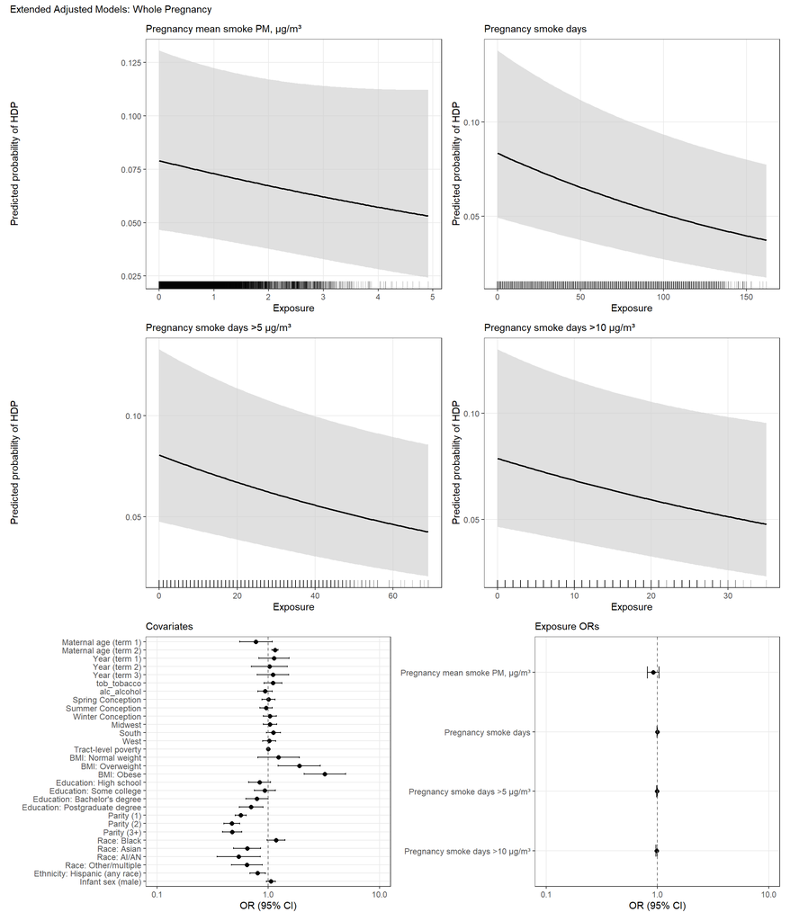

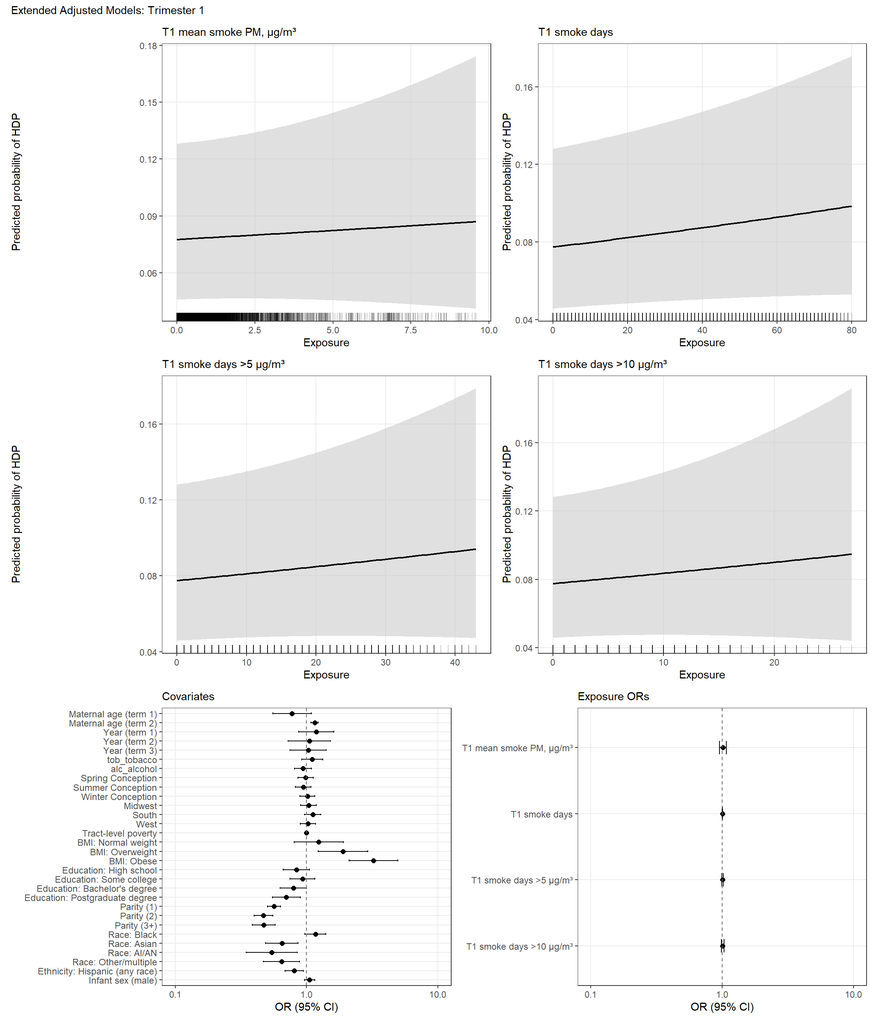

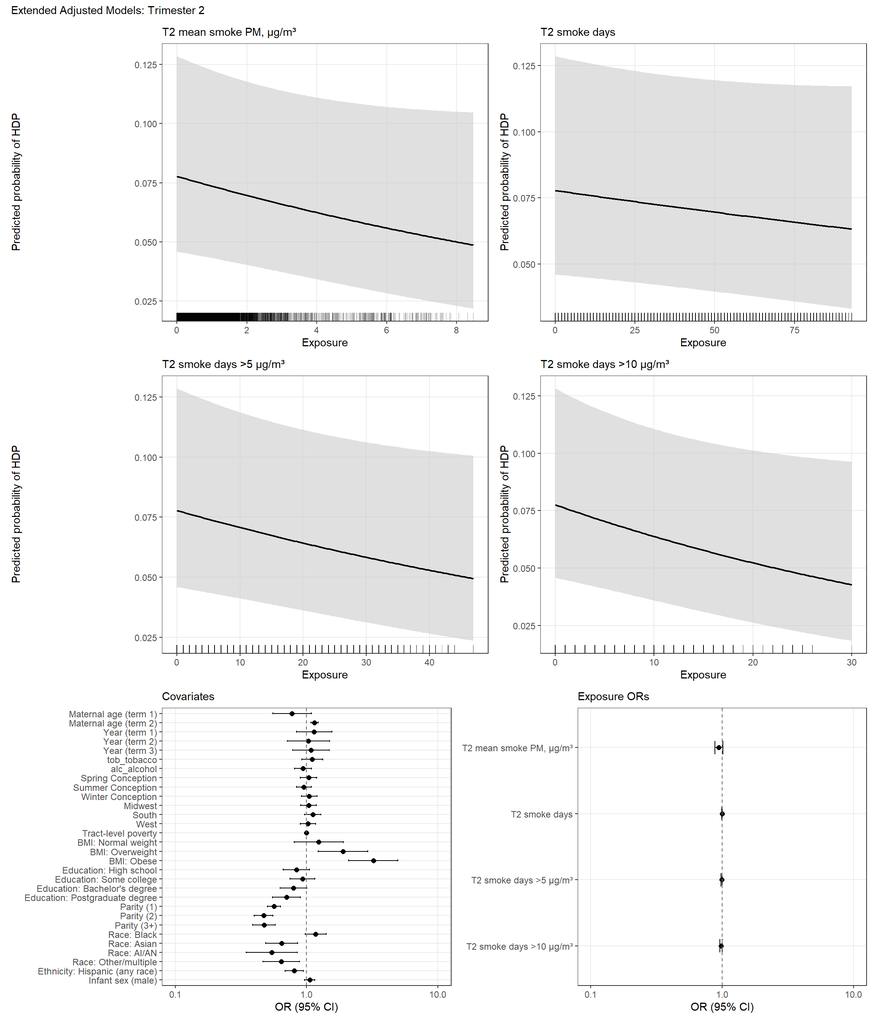

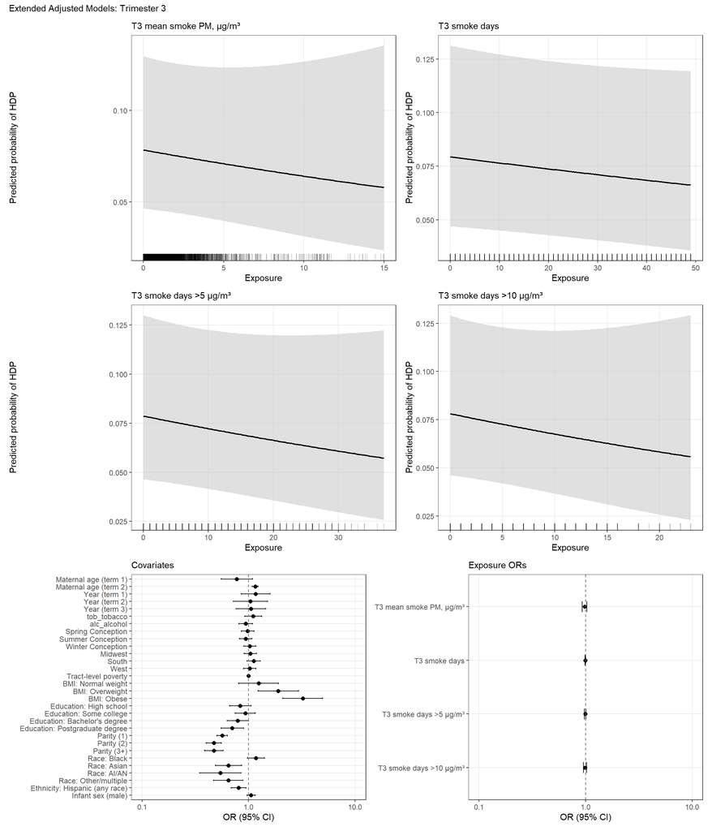